# Lab Vision Sytems: Session 1

## Organization

Please download the materials for the first session from the course website

- **Username**: VisionLabSS21
- **Password**: Resnet50

# Today:

#### 1- Python Basics

#### 2- PyTorch Basics

#### 3- A Simple Neural Net

#### 4- Dataset and Data Loading

# 1- Python Basics

### Basics and Shortcuts

- 'a': Add new cell
- 'dd': Delete cell ('d' twice)
- 'z': Undo last operation
- 'c': Copy cell
- 'v': Paste below

```python
## Shortcuts
```

```python
print("My name is Angel")
```

```
My name is Angel
```

```python
a = 5 +1
print(f"5 + 1 is {a}")
```

```
5 + 1 is 6
```

```python
raise NotImplementedError(f"Error number {a}")
```

```
---------------------------------------------------------------------------
NotImplementedError                       Traceback (most recent call last)
<ipython-input-9-0567dbdfaa6e> in <module>
----> 1 raise NotImplementedError(f"Error number {a}")

NotImplementedError: Error number 6
```

### Magic Functions

```python
#Note magics! https://ipython.readthedocs.io/en/stable/interactive/magics.html
%time a = [i for i in range(int(1e3))]
```

[output not shown]

```python
%%time
def compute(n_iters):
    for _ in range(n_iters):
        pass
compute( int(1e3) )
# compute( int(1e6) )
# compute( int(1e8) )
```

```
CPU times: user 39 µs, sys: 13 µs, total: 52 µs
Wall time: 55.1 µs
```

### Debugging

```python
"""
PDB is the Python debugger module.
Very usefull for debugging and profiling purposes
"""
import pdb
def hi_bye():
    print("hello")
    pdb.set_trace()
    print("goodbye")
hi_bye()
```

```
hello
> <ipython-input-19-ebbc85f4169b>(9)hi_bye()
      6 def hi_bye():
      7     print("hello")
      8     pdb.set_trace()
----> 9     print("goodbye")
     10 hi_bye()
```

```
goodbye
```

```python
def add_numbers(n1, n2):
    """ Adding two numbers :) """
    import pdb; pdb.set_trace()
    answer = n1 + n2
    return answer

def divide_numbers(n1, n2):
    """ Dividing two numbers :) """
    answer = n1 / n2
    return answer

def call_add(n1, n2):
    result = add_numbers(n1, n2)
    return result
```

```python
add_numbers(2, 3)
```

```
> <ipython-input-20-fe1a2a429b59>(4)add_numbers()
      2     """ Adding two numbers :) """
      3     import pdb; pdb.set_trace()
----> 4     answer = n1 + n2
      5     return answer
      6
```

```
5
```

```python
# Debug magic: %debug
# divide_numbers(10, 2)
divide_numbers(10, 0)
```

```
---------------------------------------------------------------------------
ZeroDivisionError                         Traceback (most recent call last)
<ipython-input-24-7a619002f584> in <module>
      1 # Debug magic: %debug
      2 # divide_numbers(10, 2)
----> 3 divide_numbers(10, 0)

<ipython-input-20-fe1a2a429b59> in divide_numbers(n1, n2)
      7 def divide_numbers(n1, n2):
      8     """ Dividing two numbers :) """
----> 9     answer = n1 / n2
     10     return answer
     11

ZeroDivisionError: division by zero
```

```python
%debug
```

```
> <ipython-input-20-fe1a2a429b59>(9)divide_numbers()
      7 def divide_numbers(n1, n2):
      8     """ Dividing two numbers :) """
----> 9     answer = n1 / n2
     10     return answer
     11
```

```
10
```

```
0
```

### Plotting and Visualization

```python
%matplotlib inline

import matplotlib.pyplot as plt
import numpy as np
import scipy.misc

print(np.__version__)
```

```
1.19.2
```

```
(768, 1024, 3)
```

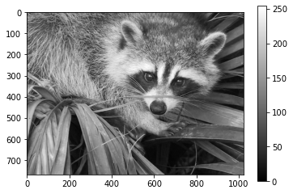

```python
a = scipy.misc.face()
print(a.shape)
# plt.imshow(a[:,:,0])
plt.imshow(a[:,:,0], cmap=plt.cm.gray)
plt.colorbar()
plt.show()
```

[figure not shown]

```python
#OPENCV
import cv2

cap = cv2.VideoCapture(0)

# Capture frame-by-frame
ret, frame = cap.read()

# Our operations on the frame come here
gray = cv2.cvtColor(frame, cv2.COLOR_BGR2GRAY)
plt.imshow(gray,cmap=plt.cm.gray)

# When everything done, release the capture
cap.release()
cv2.destroyAllWindows()
```

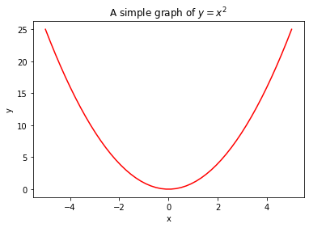

```python
# Create an array of 50 values for x equally spaced from -5 to 5.
x = np.linspace(start=-5, stop=5.0, num=50)
# x2 = np.arange(start=-5, stop=5.0, step=0.2)
# print( np.linalg.norm(x-x2) )

y = x**2

# Plot y versus x
fig, ax = plt.subplots(nrows=1, ncols=1)
ax.plot(x, y, color='red')
ax.set_xlabel('x')
ax.set_ylabel('y')
ax.set_title('A simple graph of $y=x^2$');
```

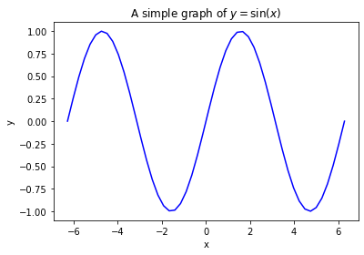

```python
x = np.linspace(start=-2*np.pi, stop=2*np.pi, num=50)
y = np.sin(x)

# Plot y versus x
fig, ax = plt.subplots(nrows=1, ncols=1)
ax.plot(x, y, color='blue')
ax.set_xlabel('x')
ax.set_ylabel('y')

# xticks = [-2*np.pi + i*np.pi/2 for i in range(8)]
# ax.set_xticks(xticks)
# xlabels = ["$-2\pi$", "$-3\pi/2$", "$-\pi$", "$-\pi\2$",
#            "$0$", "$\pi/2$", "$\pi$", "$3\pi/2$"]
# ax.set_xticklabels(xlabels)

ax.set_title('A simple graph of $y=\sin(x)$');
```

Above, you should see a plot of $y=x^2$.

You can edit this code and re-run it. For a list of valid functions, see the [NumPy Reference Manual](http://docs.scipy.org/doc/numpy/reference/routines.math.html). You can also update the plot title and axis labels.

Text in the plot as well as narrative text in the notebook can contain equations that are formatted using $\LaTeX$. To edit text written in $\LaTeX$, double click on the text or press `ENTER` when the text is selected.

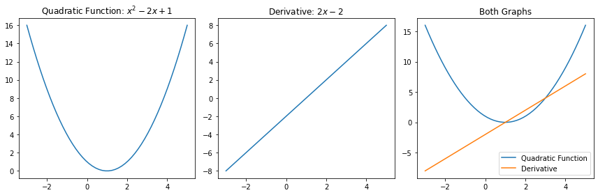

```python
x = np.linspace(start=-3, stop=5, num=50)
y1 = x**2 - 2*x + 1
y2 = 2*x - 2

# Object Oriented Matplotlib
fig, ax = plt.subplots(1,3)
fig.set_size_inches(12, 4)
ax[0].plot(x, y1)
ax[0].set_title("Quadratic Function: $x^2 - 2x + 1$")
ax[1].plot(x, y2)
ax[1].set_title("Derivative: $2x - 2$")
ax[2].plot(x, y1, label="Quadratic Function")
ax[2].plot(x, y2, label="Derivative")
ax[2].legend(loc="best")
ax[2].set_title("Both Graphs")
plt.tight_layout()
plt.show()
```

# ------------------------------------------------------------------------------------------------------------

# 2. What is PyTorch?

================

It’s a Python based scientific computing package targeted at two sets of audiences:

- A replacement for numpy to use the power of GPUs
- a deep learning research platform that provides maximum flexibility and speed

#### https://pytorch.org/docs/stable/index.html

#### https://pytorch.org/vision/stable/index.html

## Getting Started

### Tensor

Tensors are similar to numpy’s ndarrays, with the addition being that Tensors can also be used on a GPU to accelerate computing.

```python
import torch
print(torch.__version__)
```

```
1.8.1
```

Construct a 5x3 matrix, uninitialized:

```python
x = torch.Tensor(5, 3)
print(x)
```

```
tensor([[ 1.4013e-45,  0.0000e+00,  5.9854e+15],
        [ 3.0684e-41,  1.4013e-45,  0.0000e+00],
        [ 5.9852e+15,  3.0684e-41,  3.3631e-44],
        [ 3.0684e-41, -1.2848e-34,  4.5670e-41],
        [ 2.8026e-45,  4.5670e-41,  2.8026e-45]])
```

```python
x = torch.empty(5, 3)
print(x)
```

```
tensor([[0.0000e+00, 0.0000e+00, 0.0000e+00],
        [0.0000e+00, 5.9831e+15, 3.0684e-41],
        [0.0000e+00, 0.0000e+00, 1.4013e-45],
        [0.0000e+00, 2.1019e-44, 0.0000e+00],
        [0.0000e+00, 0.0000e+00, 0.0000e+00]])
```

```python
#Construct a matrix filled zeros and of dtype long:
x = torch.zeros(5, 3, dtype=torch.long)
print(x)
```

```
tensor([[0, 0, 0],
        [0, 0, 0],
        [0, 0, 0],
        [0, 0, 0],
        [0, 0, 0]])
```

```python
#Construct a tensor directly from data:
x = torch.tensor([[5.5, 3],[1,2]])
print(x)
```

```
tensor([[5.5000, 3.0000],
        [1.0000, 2.0000]])
```

```python
#copy by reference
xtmp = x
xtmp[0,0] = 9
print(xtmp)
print(x)
```

```
tensor([[9., 3.],
        [1., 2.]])
tensor([[9., 3.],
        [1., 2.]])
```

```python
xtmp = x.clone()
xtmp[0]=7
print(xtmp)
print(x)
```

```
tensor([[7., 7.],
        [1., 2.]])
tensor([[9., 3.],
        [1., 2.]])
```

Construct a randomly initialized matrix

```python
x = torch.randn(3,3)
print(x)
```

```
tensor([[ 0.0355,  0.3833,  0.6357],
        [ 0.8879, -0.5753,  1.1298],
        [-0.6318,  0.3087, -1.6446]])
```

```python
x = torch.randint(low=-5, high=5, size=(3,3))
print(x)
print(x.float())
```

```
tensor([[-1,  0, -3],
        [-5, -3, -4],
        [ 2, -5,  2]])
tensor([[-1.,  0., -3.],
        [-5., -3., -4.],
        [ 2., -5.,  2.]])
```

#### Get the current default floating point torch.dtype

```python
torch.get_default_dtype()
```

```
torch.float32
```

#### default dtype for a tensor can only be a float type

```python
torch.set_default_dtype(torch.int)
```

```
---------------------------------------------------------------------------
TypeError                                 Traceback (most recent call last)
<ipython-input-61-52038df6b50f> in <module>
----> 1 torch.set_default_dtype(torch.int)

~/anaconda3/lib/python3.8/site-packages/torch/__init__.py in set_default_dtype(d)
    330
    331     """
--> 332     _C._set_default_dtype(d)
    333
    334 def use_deterministic_algorithms(d):

TypeError: only floating-point types are supported as the default type
```

#### The default floating point dtype is initially torch.float32

#### Set the default floating point to torch.float64

```python
torch.set_default_dtype(torch.float64)
```

```python
torch.get_default_dtype()
```

```
torch.float64
```

## Creating Tensors

```python
tensor_arr = torch.Tensor([[1,2,3], [4,5,6]])
tensor_arr
```

```
tensor([[1., 2., 3.],
        [4., 5., 6.]])
```

```python
torch.is_tensor(tensor_arr)
```

```
True
```

#### numel() returns the number of elements in a tensor

```python
torch.numel(tensor_arr)
```

```
6
```

```python
tensor_arr.shape
```

```
torch.Size([2, 3])
```

## Torch Tensor Datatypes

Tensors can be set to have specific data types

```python
tensor_int = torch.tensor([5, 3]).type(torch.IntTensor) #This is on CPU if you want it on GPU you can use torch.cuda.IntTensor
tensor_int
```

```
tensor([5, 3], dtype=torch.int32)
```

#### A Tensor of type short

```python
tensor_short = torch.tensor([1.0, 2.0, 3.0], dtype=torch.int16)
tensor_short
```

```
tensor([1, 2, 3], dtype=torch.int16)
```

#### A Tensor of type float half (float16)

```python
tensor_float = torch.tensor([1.0, 2.0, 3.0]).type(torch.half)
tensor_float
```

```
tensor([1., 2., 3.], dtype=torch.float16)
```

#### A tensor filled with a specific values

```python
tensor_fill = torch.full((2, 6), fill_value=10)
tensor_fill
```

```
tensor([[10, 10, 10, 10, 10, 10],
        [10, 10, 10, 10, 10, 10]])
```

#### A tensor of size (2,4) containing all ones

```python
tensor_of_ones = torch.ones([2, 4], dtype=torch.int32)
tensor_of_ones
```

```
tensor([[1, 1, 1, 1],
        [1, 1, 1, 1]], dtype=torch.int32)
```

#### A tensor of size (2,4) like tensor_of_ones containing all zeroes

```python
tensor_of_zeroes = torch.zeros_like(tensor_of_ones)
tensor_of_zeroes
```

```
tensor([[0, 0, 0, 0],
        [0, 0, 0, 0]], dtype=torch.int32)
```

#### Create an identity 5X5 tensor

```python
tensor_eye = torch.eye(5)
tensor_eye
```

```
tensor([[1., 0., 0., 0., 0.],
        [0., 1., 0., 0., 0.],
        [0., 0., 1., 0., 0.],
        [0., 0., 0., 1., 0.],
        [0., 0., 0., 0., 1.]])
```

```python
tensor_eye = tensor_eye.fill_diagonal_(5)
tensor_eye
```

```
tensor([[5., 0., 0., 0., 0.],
        [0., 5., 0., 0., 0.],
        [0., 0., 5., 0., 0.],
        [0., 0., 0., 5., 0.],
        [0., 0., 0., 0., 5.]])
```

#### Get the list of indices of non-zero elements in a tensor

[ i, j ] index for non-zero elements

```python
non_zero = torch.nonzero(tensor_eye)
non_zero
```

```
tensor([[0, 0],
        [1, 1],
        [2, 2],
        [3, 3],
        [4, 4]])
```

## Sparse Tensors

Create a sparse tensor using coordinates specified by indices and values

```python
i = torch.tensor([[0, 1, 1],
                  [2, 2, 0]])
```

```python
v = torch.tensor([3, 4, 5], dtype=torch.float32)
```

```python
sparse_tensor = torch.sparse_coo_tensor(i, v, [2, 5])
```

```python
sparse_tensor.data
```

```
tensor(indices=tensor([[0, 1, 1],
                       [2, 2, 0]]),
       values=tensor([3., 4., 5.]),
       size=(2, 5), nnz=3, dtype=torch.float32, layout=torch.sparse_coo)
```

```python
sparse_tensor.to_dense()
```

```
tensor([[0., 0., 3., 0., 0.],
        [5., 0., 4., 0., 0.]], dtype=torch.float32)
```

## Inplace / Out-of-place

The first difference is that ALL operations on the tensor that operate in-place on it will have an "_" postfix. For example, add is the out-of-place version, and add_ is the in-place version.

#### .fill_ is in-place operation and it doesnt have any out-place equivalent

```python
initial_tensor = torch.rand(2, 3)

initial_tensor
```

```
tensor([[0.5757, 0.6673, 0.6510],
        [0.7886, 0.2589, 0.0148]])
```

```python
initial_tensor.fill_(10)
```

```
tensor([[10., 10., 10.],
        [10., 10., 10.]])
```

```python
# initial_tensor.fill(10)
newT=torch.ones_like(initial_tensor)*10
newT
```

```
tensor([[10., 10., 10.],
        [10., 10., 10.]])
```

#### The add() method does an out-of-place add operation and returns a new tensor

This is assigned to the new_tensor variable

```python
initial_tensor = torch.ones_like(initial_tensor)*10
new_tensor = initial_tensor.add(5)
print(new_tensor)
```

```
tensor([[15., 15., 15.],
        [15., 15., 15.]])
```

#### The original tensor is unchanged

```python
initial_tensor
```

```
tensor([[10., 10., 10.],
        [10., 10., 10.]])
```

#### The add_ method does an in-place add, changing the calling tensor

```python
initial_tensor.add_(8)
initial_tensor
```

[output not shown]

#### The new_tensor was a separate copy and is unaffected

```python
new_tensor
```

```
tensor([[15., 15., 15.],
        [15., 15., 15.]])
```

#### In-place version of sqrt()

```python
new_tensor.sqrt_()
new_tensor
```

[output not shown]

## Indexing, Slicing, Joining, Mutating Ops

## Slicing

```python
x = torch.linspace(start=0., end=10.0, steps=15)
x
```

```
tensor([ 0.0000,  0.7143,  1.4286,  2.1429,  2.8571,  3.5714,  4.2857,  5.0000,
         5.7143,  6.4286,  7.1429,  7.8571,  8.5714,  9.2857, 10.0000])
```

#### Splits a tensor into a specific number of chunks.

- tensor (Tensor) – the tensor to split
- chunks (int) – number of chunks to return
- dim (int) – dimension along which to split the tensor

```python
tensor_chunk = torch.chunk(input=x, chunks=3, dim=0)
tensor_chunk
```

```
(tensor([0.0000, 0.7143, 1.4286, 2.1429, 2.8571]),
 tensor([3.5714, 4.2857, 5.0000, 5.7143, 6.4286]),
 tensor([ 7.1429,  7.8571,  8.5714,  9.2857, 10.0000]))
```

## Concatenating and Stacking

All tensors must either have the same shape (except in the concatenating dimension) or be empty.

```python
tensor1 = tensor_chunk[0]
tensor2 = tensor_chunk[1]
tensor3 = tensor_chunk[2]

# concatenating along first (and only) dimension
cat1 = torch.cat([tensor1, tensor2, tensor3], dim=0)
print(cat1.shape)

# stacking on first dimension
cat2 = torch.stack([tensor1, tensor2, tensor3], dim=0)
print(cat2.shape)

# stacking on last dimension
cat3 = torch.stack([tensor1, tensor2, tensor3], dim=-1)
print(cat3.shape)
```

```
torch.Size([15])
torch.Size([3, 5])
torch.Size([5, 3])
```

```python
random_tensor = torch.Tensor([[10, 8, 30], [40, 5, 6], [12, 2, 21]])
random_tensor
```

```
tensor([[10.,  8., 30.],
        [40.,  5.,  6.],
        [12.,  2., 21.]])
```

```python
random_tensor[0, 1]
```

```
tensor(8.)
```

```python
random_tensor[1:, 1:]
```

```
tensor([[ 5.,  6.],
        [ 2., 21.]])
```

#### Splits the tensor into chunks

```python
random_tensor_split = torch.split(random_tensor, 2)
random_tensor_split
```

```
(tensor([[10.,  8., 30.],
         [40.,  5.,  6.]]),
 tensor([[12.,  2., 21.]]))
```

## View and Reshape

```python
random_tensor = torch.randint(low=0, high=5, size=(3,3)).float()
random_tensor
```

```
tensor([[0., 3., 4.],
        [1., 1., 3.],
        [0., 4., 1.]], dtype=torch.float32)
```

```python
random_tensor.shape
# random_tensor.size()
```

```
torch.Size([3, 3])
```

```python
resized_tensor = random_tensor.view(9)
resized_tensor
```

```
tensor([0., 3., 4., 1., 1., 3., 0., 4., 1.], dtype=torch.float32)
```

```python
# -1 groups all missing elements
resized_tensor = random_tensor.view(-1, 3)
resized_tensor
```

```
tensor([[0., 3., 4.],
        [1., 1., 3.],
        [0., 4., 1.]], dtype=torch.float32)
```

```python
resized_tensor.size()
```

```
torch.Size([3, 3])
```

#### view() & reshape() does not create a deep copy - just a view as the name suggests

Modifying the original tensor affects the resized_tensor as they both point to the same space in memory

```python
random_tensor[2, 2] = 100.05
resized_tensor
```

```
tensor([[  0.0000,   3.0000,   4.0000],
        [  1.0000,   1.0000,   3.0000],
        [  0.0000,   4.0000, 100.0500]], dtype=torch.float32)
```

## Squeezing and Unsqueezing

Returns a new tensor with a dimension of size one inserted at the specified position.

```python
random_tensor = torch.randint(low=0, high=5, size=(3,3)).float()
random_tensor
```

```
tensor([[1., 0., 0.],
        [4., 2., 3.],
        [3., 1., 4.]], dtype=torch.float32)
```

```python
random_tensor.shape
```

```
torch.Size([3, 3])
```

```python
# adding a new dimension in position 2
tensor_unsqueeze = random_tensor.unsqueeze(dim=2)
tensor_unsqueeze.shape
```

```
torch.Size([3, 3, 1])
```

```python
# removing empty dimension in position 2
tensor_unsqueeze.squeeze(2).shape
```

```
torch.Size([3, 3])
```

```python
# using squeeze removes all dimensions of size 1
tensor_unsqueeze = random_tensor.unsqueeze(dim=-1).unsqueeze(dim=-1)
print(tensor_unsqueeze.shape)
tensor_squeeze = tensor_unsqueeze.squeeze()
print(tensor_squeeze.shape)
```

```
torch.Size([3, 3, 1, 1])
torch.Size([3, 3])
```

## Transposing and Permuting

#### Transpose returns a tensor that is a transposed version of the input. The given dimensions dim0 and dim1 are swapped.

```python
initial_tensor = torch.ones(2,3)
print(initial_tensor)
print(initial_tensor.shape)
```

```
tensor([[1., 1., 1.],
        [1., 1., 1.]])
torch.Size([2, 3])
```

```python
tensor_transpose = initial_tensor.transpose(dim0=0, dim1=1)
print(tensor_transpose)
print(tensor_transpose.shape)
```

```
tensor([[1., 1.],
        [1., 1.],
        [1., 1.]])
torch.Size([3, 2])
```

```python
# it only works for two dimensions
initial_tensor = torch.rand(3,4,5)
transpose_0_1 = initial_tensor.transpose(0, 1)
transpose_0_2 = initial_tensor.transpose(0, 2)
transpose_1_2 = initial_tensor.transpose(1, 2)
print(f"Orig shape: {initial_tensor.shape}")
print(f"Transposed 0-1 shape: {transpose_0_1.shape}")
print(f"Transposed 0-2 shape: {transpose_0_2.shape}")
print(f"Transposed 1-2 shape: {transpose_1_2.shape}")
```

```
Orig shape: torch.Size([3, 4, 5])
Transposed 0-1 shape: torch.Size([4, 3, 5])
Transposed 0-2 shape: torch.Size([5, 4, 3])
Transposed 1-2 shape: torch.Size([3, 5, 4])
```

#### Permute allowes to simultanously permute several dimensions

```python
perm1 = initial_tensor.permute(2, 0, 1)
perm2 = initial_tensor.permute(1, 2, 0)
print(f"Orig shape: {initial_tensor.shape}")
print(f"Permutation (2,0,1) shape: {perm1.shape}")
print(f"Permutation (1,2,0) shape: {perm2.shape}")
```

```
Orig shape: torch.Size([3, 4, 5])
Permutation (2,0,1) shape: torch.Size([5, 3, 4])
Permutation (1,2,0) shape: torch.Size([4, 5, 3])
```

#### Useful for plotting. Output of a CNN has shape (B,C,H,W), whereas Matplotlib plots with the color-channel in the las dimension

- ```
  img_plot = out_cnn[0].permute(1,2,0)  # selecting first element in the batch and permuting for plot
  ```

## Sorting tensors

Tensors can be sorted along a specified dimension. If no dimension is specified, the last dimension is picked by default

```python
random_tensor
```

```
tensor([[1., 0., 0.],
        [4., 2., 3.],
        [3., 1., 4.]], dtype=torch.float32)
```

```python
sorted_tensor, sorted_indices = torch.sort(random_tensor)  #Default last dim of the Tensor
```

```python
sorted_tensor
```

```
tensor([[0., 0., 1.],
        [2., 3., 4.],
        [1., 3., 4.]], dtype=torch.float32)
```

```python
sorted_indices
```

```
tensor([[1, 2, 0],
        [1, 2, 0],
        [1, 0, 2]])
```

# Math Operations

Pytorch supports a number of mathematical operations which can be performed on tensors. We take a look at a few of them here

```python
tensor_float = torch.FloatTensor([-1.1, -2.2, 3.3])
tensor_float
```

```
tensor([-1.1000, -2.2000,  3.3000], dtype=torch.float32)
```

### Basic Ops

```python
# absolute value
tensor_abs = torch.abs(tensor_float)
# tensor_abs = tensor_float.abs()
tensor_abs
```

```
tensor([1.1000, 2.2000, 3.3000], dtype=torch.float32)
```

```python
initial_tensor = torch.rand(2,2)
initial_tensor
```

```
tensor([[0.8466, 0.1670],
        [0.5459, 0.2443]])
```

```python
new_tensor = torch.add(initial_tensor, 2)
new_tensor
```

```
tensor([[2.8466, 2.1670],
        [2.5459, 2.2443]])
```

#### Element-wise division

The div() and mul() functions can be used to divide and multiply the values in a tensor. Here, we do an element-wise division between two tensors

```python
tensor = torch.Tensor([[-1, -2, -3],
                       [ 1,  2,  3]])
```

```python
tensor_div = torch.div(tensor, tensor + 1)
tensor_div
```

```
tensor([[  -inf, 2.0000, 1.5000],
        [0.5000, 0.6667, 0.7500]])
```

#### Element-wise multiplicaton

```python
tensor_mul = torch.mul(tensor, tensor)
tensor_mul
```

```
tensor([[1., 4., 9.],
        [1., 4., 9.]])
```

## Chaining Operations

We can easily chain several operations in one line:

$ MSE(X,Y) = \frac{1}{N}\sum_{i=0}^{N-1}(x_i - y_i)^2 $

```python
# MSE
x = torch.rand(3,3)
y = torch.rand(3,3)
mse_ours = (x - y).pow(2).sum().div(9)

import torch.nn.functional as F
mse_torch = F.mse_loss(x,y)

print(f"MSE ours:  {mse_ours}")
print(f"MSE torch: {mse_torch}")
```

```
MSE ours:  0.06027244336951787
MSE torch: 0.06027244336951787
```

## Clamp the value of a Tensor

There will be occasions where you would like to set upper and lower limits for the values in a tensor. This is where the clamp function is used. The value of an element is set to:

- min if if x<sub>i</sub> < min
- x<sub>i</sub> if min < x<sub>i</sub> < max
- max if x<sub>i</sub> > max

Very useful to display tensors in which there are values above 255 or below 0.

```python
tensor
```

```
tensor([[-1., -2., -3.],
        [ 1.,  2.,  3.]])
```

```python
tensor_clamp = torch.clamp(tensor, min= -0.2, max=2)
tensor_clamp
```

```
tensor([[-0.2000, -0.2000, -0.2000],
        [ 1.0000,  2.0000,  2.0000]])
```

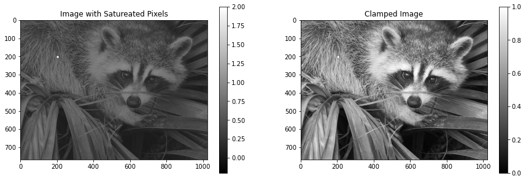

```python
img = scipy.misc.face() / 255
img = torch.Tensor(img)
img[200:210, 200:210] = 2
img[652,222] = -.2
img_clamp = img.clamp(min=0, max=1)

fig, ax = plt.subplots(1,2)
fig.set_size_inches(15,5)

im = ax[0].imshow(img[:,:,0], cmap=plt.cm.gray)
fig.colorbar(im, ax=ax[0])
ax[0].set_title("Image with Satureated Pixels")

im = ax[1].imshow(img_clamp[:,:,0], cmap=plt.cm.gray)
fig.colorbar(im, ax=ax[1])
ax[1].set_title("Clamped Image")

plt.show()
```

## Vector Multiplication

#### Dot product

```python
t1 = torch.Tensor([1, 2])
t2 = torch.Tensor([10, 20])
```

```python
dot_product = torch.dot(t1, t2)
dot_product
```

```
tensor(50.)
```

## Matrix Vector product

If mat is a (n×m) tensor, vec is a 1-D tensor of size m, out will be 1-D of size n.

```python
matrix = torch.Tensor([[1, 2, 3],
                       [4, 5, 6]])

vector = torch.Tensor([0, 1, 2])
```

```python
matrix_vector = torch.mv(matrix, vector)
matrix_vector
```

```
tensor([ 8., 17.])
```

## Matrix multiplication

```python
another_matrix = torch.Tensor([[10, 30],
                               [20, 0],
                               [0 , 50]])
```

```python
print(matrix.shape)
print(another_matrix.shape)
```

```
torch.Size([2, 3])
torch.Size([3, 2])
```

```python
matrix_mul = torch.mm(matrix, another_matrix)
matrix_mul
```

```
tensor([[ 50., 180.],
        [140., 420.]])
```

```python
matrix_mul = torch.mm(matrix, another_matrix.T)
matrix_mul
```

```
---------------------------------------------------------------------------
RuntimeError                              Traceback (most recent call last)
<ipython-input-169-8e80cc3515d3> in <module>
----> 1 matrix_mul = torch.mm(matrix, another_matrix.T)
      2 matrix_mul

RuntimeError: mat1 and mat2 shapes cannot be multiplied (2x3 and 2x3)
```

## Batch Matrix Multiplication

```python
m1 = torch.zeros(2,3)
m2 = torch.ones(2,3)
matrix = torch.stack([m1,m2])
print(matrix.shape)
```

```
torch.Size([2, 2, 3])
```

```python
another_matrix = torch.Tensor([[10, 30], [20, 0], [0 , 50]])
another_matrix = another_matrix.unsqueeze(0).repeat(2,1,1)
print(another_matrix.shape)
```

```
torch.Size([2, 3, 2])
```

```python
matrix_mul = torch.bmm(matrix, another_matrix)
```

```python
matrix_mul
```

```
tensor([[[ 0.,  0.],
         [ 0.,  0.]],

        [[30., 80.],
         [30., 80.]]])
```

## Argmax & Argmin

#### Indices of the maximum values of a tensor across a dimension.

```python
m1 = torch.arange(0,10)
m2 = torch.arange(10,0, -1)
matrix = torch.stack([m1,m2])
matrix
```

```
tensor([[ 0,  1,  2,  3,  4,  5,  6,  7,  8,  9],
        [10,  9,  8,  7,  6,  5,  4,  3,  2,  1]])
```

```python
torch.argmax(matrix, dim=1)
```

```
tensor([9, 0])
```

```python
torch.argmin(matrix, dim=1)
```

```
tensor([0, 9])
```

```python
# if you dont specifiy, it linearizes
amax = torch.argmax(matrix)
amax
```

```
tensor(10)
```

```python
n_cols = matrix.shape[1]
row, col = amax // n_cols, amax % n_cols
print(f"arg max: row {row} & col {col}")
```

```
arg max: row 1 & col 0
```

## Seeds for Reproducibility

We want to be able to reproduce our work. To remove randomness, we manually choose random seeds for reproducibility.

```python
# different every time
x = torch.rand(5, 3)
print(x)
```

```
tensor([[0.7995, 0.6167, 0.3210],
        [0.6531, 0.6325, 0.1040],
        [0.3692, 0.5613, 0.9874],
        [0.0076, 0.7148, 0.7342],
        [0.2595, 0.9265, 0.6028]])
```

```python
# always same randomness
torch.manual_seed(13)
x = torch.rand(5, 3)
print(x)
```

```
tensor([[0.7345, 0.4844, 0.1224],
        [0.8544, 0.8871, 0.6640],
        [0.3190, 0.2783, 0.0241],
        [0.6933, 0.7548, 0.2245],
        [0.8336, 0.2608, 0.6050]])
```

```python
np.random.seed(13)
np.random.rand(2,2)
```

```
array([[0.77770241, 0.23754122],
       [0.82427853, 0.9657492 ]])
```

```python
import os, random

CONFIG = {
    "random_seed": 13
}

def set_random_seed(random_seed=None):
    """
    Generalizing random seed
    """
    if(random_seed is None):
        random_seed = CONFIG["random_seed"]
    os.environ['PYTHONHASHSEED'] = str(random_seed)
    random.seed(random_seed)
    np.random.seed(random_seed)
    torch.manual_seed(random_seed)
    if torch.cuda.is_available():
        torch.cuda.manual_seed_all(random_seed)
    return

set_random_seed()
```

## Read later:

100+ Tensor operations, including transposing, indexing, slicing, mathematical operations, linear algebra, random numbers, etc are described here: http://pytorch.org/docs/torch

## Numpy Bridge

Converting a torch Tensor to a numpy array and vice versa is a breeze.

The torch Tensor and numpy array will share their underlying memory locations, and changing one will change the other.

### Converting torch Tensor to numpy Array

```python
a = torch.zeros(5)
print(a)
```

```
tensor([0., 0., 0., 0., 0.])
```

```python
print(type(a))
b = a.numpy()
print(b)
print(type(b))
```

```
<class 'torch.Tensor'>
[0. 0. 0. 0. 0.]
<class 'numpy.ndarray'>
```

See how the numpy array changed in value.

```python
a.add_(1)
print(a)
print(b)
```

```
tensor([1., 1., 1., 1., 1.])
[1. 1. 1. 1. 1.]
```

### Converting numpy Array to torch Tensor

See how changing the np array changed the torch Tensor automatically

```python
import numpy as np
a = np.ones(5)
b = torch.from_numpy(a)
np.add(a, 1, out=a)
print(a)
print(b)
```

```
[2. 2. 2. 2. 2.]
tensor([2., 2., 2., 2., 2.])
```

```python
np_array_new = np.ones((2,2),dtype=np.int32)
torch_from_np = torch.from_numpy(np_array_new) # The only supported types are: double, float32 , float64, int64, int32, and uint8
torch_from_np
```

```
tensor([[1, 1],
        [1, 1]], dtype=torch.int32)
```

```python
torch_tensor = torch.Tensor(np_array_new)
torch_tensor
```

```
tensor([[1., 1.],
        [1., 1.]])
```

## Interoperablity between Numpy arrays and Pytorch Tensors

```python
import numpy as np
import torch
```

```python
tensor = torch.rand(2, 2)
id(tensor)
```

```
139977724663232
```

### The numpy arrays use the same memory as the PyTorch tensor

```python
numpy_from_tensor = tensor.numpy()
numpy_from_tensor
```

```
array([[0.73453646, 0.4844107 ],
       [0.12242455, 0.85436448]])
```

```python
type(numpy_from_tensor)
```

```
numpy.ndarray
```

```python
torch.is_tensor(tensor)
```

```
True
```

```python
torch.is_tensor(numpy_from_tensor)
```

```
False
```

#### The NumPy array and the Torch tensor share memory

```python
numpy_from_tensor[0, 0] = 100.0

numpy_from_tensor
```

```
array([[100.        ,   0.4844107 ],
       [  0.12242455,   0.85436448]])
```

```python
tensor
```

```
tensor([[100.0000,   0.4844],
        [  0.1224,   0.8544]])
```

#### Converting a numpy array to a Tensor

```python
numpy_arr = np.array([[1.0, 2.0, 3.0],
                      [10.0, 20.0, 30.0],
                      [100.0, 200.0, 300.0]])

numpy_arr
```

```
array([[  1.,   2.,   3.],
       [ 10.,  20.,  30.],
       [100., 200., 300.]])
```

```python
tensor_from_numpy = torch.from_numpy(numpy_arr)
tensor_from_numpy
```

```
tensor([[  1.,   2.,   3.],
        [ 10.,  20.,  30.],
        [100., 200., 300.]])
```

```python
type(tensor_from_numpy)
```

```
torch.Tensor
```

```python
torch.is_tensor(tensor_from_numpy)
```

```
True
```

#### The Numpy arrays and Tensor share the same memory

The tensor and numpy_from_tensor are shallow copies and share the same memory as the original numpy array. Modifying the original array affects the values of both tensor and numpy_from_tensor

```python
tensor_from_numpy[0] = 1
tensor_from_numpy
```

```
tensor([[  1.,   1.,   1.],
        [ 10.,  20.,  30.],
        [100., 200., 300.]])
```

```python
numpy_arr
```

```
array([[  1.,   1.,   1.],
       [ 10.,  20.,  30.],
       [100., 200., 300.]])
```

#### Convert the data into a torch.Tensor.

If the data is already a Tensor with the same dtype and device, no copy will be performed, otherwise a new Tensor will be returned

```python
np_array_one = np.array([4, 8])
np_array_one
```

```
array([4, 8])
```

```python
tensor_from_array_one = torch.as_tensor(np_array_one) #Performs copy if the data is not already a tensor
tensor_from_array_one
```

```
tensor([4, 8])
```

```python
np_array_one[1] = 5
np_array_one
```

```
array([4, 5])
```

```python
tensor_from_array_one
```

```
tensor([4, 5])
```

#### torch.tensor() and torch.Tensor() read out the data from whatever it is passed, and constructs a leaf variable

```python
np_array_two = np.array([2, 2])
np_array_two
```

```
array([2, 2])
```

```python
tensor_from_array_two = torch.tensor(np_array_two)#Always copy

tensor_from_array_two
```

```
tensor([2, 2])
```

#### in this method the tensor and array do not share memory

```python
np_array_two[1] = 4
np_array_two
```

```
array([2, 4])
```

```python
tensor_from_array_two
```

```
tensor([2, 2])
```

All the Tensors on the CPU except a CharTensor support converting to NumPy and back.

## CUDA Tensors

Tensors can be moved onto GPU using the `.cuda` function.

- To run Jupyter or a Python scrip with CUDA, you need to preprend `CUDA_VISIBLE_DEVICES=ID` to the call
- Connect to server with forwarding option

  ```
  ssh -L localhost:9999:localhost:9999 villar@bigcuda4.informatik.uni-bonn.de
  ```

- Start serving Jupyter Lab

  ```
  CUDA_VISIBLE_DEVICES=0 jupyter lab --no-browser --port=9999
  ```

```python
torch.cuda.is_available()
```

```
True
```

```python
# let us run this cell only if CUDA is available
if torch.cuda.is_available():
    x, y = torch.ones(2), torch.ones(2)
    x = x.cuda()
    y = y.cuda()
    print(type(y))
    print(x + y)
    print(type(x+y))
    ycpu=y.cpu()
    print(type(ycpu))
```

```
<class 'torch.Tensor'>
tensor([2., 2.], device='cuda:0')
<class 'torch.Tensor'>
<class 'torch.Tensor'>
```

```python
# let us run this cell only if CUDA is available
# We will use ``torch.device`` objects to move tensors in and out of GPU
if torch.cuda.is_available():
    device = torch.device("cuda")          # a CUDA device object
    y = torch.ones_like(x, device=device)  # directly create a tensor on GPU
    x = x.to(device)                       # or just use strings ``.to("cuda")``
    z = x + y
    print(z)
    print(z.to("cpu", torch.double))       # ``.to`` can also change dtype together!
```

```
tensor([2., 2.], device='cuda:0')
tensor([2., 2.])
```

```python
# the magic line
device = torch.device("cuda" if torch.cuda.is_available() else "cpu")
```

```python
x = x.to(device)
```

## Cuda

```python
torch.cuda.is_available()
```

```
True
```

```python
# Initialize PyTorch’s CUDA state. You may need to call this explicitly if you are interacting
# with PyTorch via its C API

torch.cuda.init()
```

```python
torch.cuda.current_device()
```

```
0
```

```python
torch.cuda.device_count()
```

```
1
```

```python
torch.cuda.memory_allocated()
```

```
1536
```

```python
torch.cuda.memory_cached() #Behind the scenes Pytorch uses a caching memory allocator to speed up memory allocations
#this allows fast memory deallocation withput device synchronizations
```

```
2097152
```

```python
cuda = torch.device('cuda') #device context manager

cuda
```

```
device(type='cuda')
```

```python
cuda0 = torch.device('cuda:0')
cuda1 = torch.device('cuda:1')
cuda2 = torch.device('cuda:2')
```

```python
cuda0, cuda1, cuda2
```

```
(device(type='cuda', index=0),
 device(type='cuda', index=1),
 device(type='cuda', index=2))
```

```python
x = torch.tensor([10., 20.])

x
```

```
tensor([10., 20.])
```

```python
x_default = torch.tensor([10., 20.], device=cuda)

x_default
```

```
tensor([10., 20.], device='cuda:0')
```

```python
x0 = torch.tensor([10., 20.], device=cuda0)

x0
```

```
tensor([10., 20.], device='cuda:0')
```

```python
x1 = torch.tensor([10., 20.], device=cuda1)

x1
```

```
---------------------------------------------------------------------------
RuntimeError                              Traceback (most recent call last)
<ipython-input-251-469f62214d5b> in <module>
----> 1 x1 = torch.tensor([10., 20.], device=cuda1)
      2
      3 x1

RuntimeError: CUDA error: invalid device ordinal
```

```python
x2 = torch.tensor([10., 20.], device=cuda2)

x2
```

```
---------------------------------------------------------------------------
RuntimeError                              Traceback (most recent call last)
<ipython-input-252-66f6bd885e23> in <module>
----> 1 x2 = torch.tensor([10., 20.], device=cuda2)
      2
      3 x2

RuntimeError: CUDA error: invalid device ordinal
```

### Returns a copy of this object in CUDA memory.

If this object is already in CUDA memory and on the correct device, then no copy is performed and the original object is returned.

```python
# Transferring a tensor from CPU to GPU 0
y = x.cuda()

y
```

```
tensor([10., 20.], device='cuda:0')
```

```python
print('Outside with context: ', torch.cuda.current_device())

with torch.cuda.device(0):

    print('Inside with context: ', torch.cuda.current_device())

print('Outside with context again: ', torch.cuda.current_device())
```

```
Outside with context:  0
Inside with context:  0
Outside with context again:  0
```

```python
with torch.cuda.device(0):

    a = torch.tensor([10., 20.])

    a0 = torch.tensor([10., 20.], device=cuda0)

    a1 = torch.tensor([10., 20.], device=cuda)
```

```python
a
```

```
tensor([10., 20.])
```

```python
a0
```

```
tensor([10., 20.], device='cuda:0')
```

```python
a1
```

```
tensor([10., 20.], device='cuda:0')
```

```python
sum_a = a + a0
```

```
---------------------------------------------------------------------------
RuntimeError                              Traceback (most recent call last)
<ipython-input-259-e4ab1d679b82> in <module>
----> 1 sum_a = a + a0

RuntimeError: Expected all tensors to be on the same device, but found at least two devices, cuda:0 and cpu!
```

```python
sum_a = a1 + a0
```

```python
torch.cuda.memory_allocated()
```

```
3584
```

```python
torch.cuda.memory_reserved()
```

```
2097152
```

```python
hugeTensor = torch.rand(100,100,100,100).cuda()
torch.cuda.memory_allocated()
```

```
800003584
```

```python
torch.cuda.memory_reserved()
```

```
803209216
```

```python
del hugeTensor
torch.cuda.memory_allocated()
```

```
3584
```

```python
torch.cuda.memory_reserved()
```

```
803209216
```

```python
import gc
gc.collect()
torch.cuda.empty_cache()
```

```python
torch.cuda.memory_reserved()
```

```
2097152
```

# PyTorch Vs. Tensorflow

[figure not shown]

# ------------------------------------------------------------------------------------------------------------

# 3- A Simple Neural Net

Neural networks are basically matrix multiplications

[figure not shown]

- $\mathbf{X}_{i,j}:$ is the value of the input pixel #$i$ for the element $j$ ib the batch
- $\mathbf{W}_{i,j}:$ is the weight of the connection between input neuron $i$ and output neuron $j$

## Backward

- Network parameters are updated through gradient descent
- We compute the gradients using backpropagation

Given the error tensor at layer $n$: $\mathbf{E}_n$,

- We compute the error with respect to the input ($\frac{\partial \mathbf{E}_n}{\partial \mathbf{X}}$) and backpropagate this value:
  - $\mathbf{E}_{n-1} = \mathbf{W}^T \mathbf{E}_{n}$
- Update parameters through gradient descent using the gradient with respect to the parameters ($\frac{\partial \mathbf{E}_n}{\partial \mathbf{W}}$):
  - $\mathbf{W}^{\text(new)} = \mathbf{W}^{\text(old)} - \lambda \cdot \mathbf{E}_n \mathbf{X}^T$

```python
INPUT_SIZE = 10
OUT_SIZE = 2
LR = 1e-2
```

```python
input = torch.rand(1, INPUT_SIZE)
weights = torch.rand(INPUT_SIZE, OUT_SIZE)
error = torch.rand(1, OUT_SIZE)
```

```python
# forward pass
out = torch.mm(input, weights)
```

```python
# backward pass
weights_new =  weights - LR * torch.mm(input.T, error)
```

# 4- The MNIST Dataset

Official webpage: http://yann.lecun.com/exdb/mnist/

The MNIST database contains 60,000 training images and 10,000 testing images. We can flatten this array into a vector of 28x28 = 784 numbers.

MNIST is a simple computer vision dataset. It consists of images of handwritten digits like these:

[figure not shown]

It also includes labels for each image, telling us which digit it is. For example, the labels for the above images are 5, 0, 4, and 1.

```python
import torch
import torch.nn as nn
import torchvision.transforms as transforms
import torchvision.datasets as datasets

train_dataset = datasets.MNIST(root='./data',train=True, transform=transforms.ToTensor(), download=True)
test_dataset = datasets.MNIST(root='./data',train=False, transform=transforms.ToTensor() ,download=True)
```

```python
n_imgs_train = len(train_dataset)
n_imgs_test = len(test_dataset)
```

```python
print(f"# Images Train: {n_imgs_train}")
print(f"# Images Test:  {n_imgs_test}")
```

```
# Images Train: 60000
# Images Test:  10000
```

```python
img_shape = train_dataset[0][0].shape
label = train_dataset[0][1]
```

```python
print(f"Image shape: {img_shape}")
print(f"Label: {label}")
```

```
Image shape: torch.Size([1, 28, 28])
Label: 5
```

```python
import matplotlib.pyplot as plt
%matplotlib inline
```

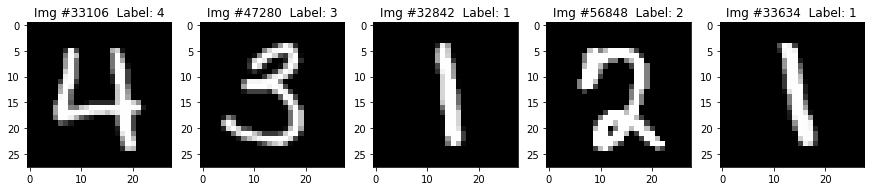

```python
fig, ax = plt.subplots(1,5)
fig.set_size_inches(15, 3)

ids = np.random.randint(low=0, high=len(train_dataset), size=5)

for i, n in enumerate(ids):
    img = train_dataset[n][0].numpy().reshape(28,28)
    ax[i].imshow(img, cmap='gray')
    ax[i].set_title(f"Img #{n}  Label: {train_dataset[n][1]}")
plt.show()
```

## Our own Dataset

In addition to using the already existing datasets, it is easy to make our own dataset by loading data or by modifying existing databases.

```python
class OurOwnDataset():
    """ Our own simple dataset """

    def __init__(self, path, train=True, transforms=None):
        """ Dataset initializer """
        assert type(train), f"Unrecognized split {train}..."

        # loading data
        data_file = "training.pt" if train else "test.pt"
        data_path = os.path.join(path, data_file)
        assert os.path.exists(data_path), f"Data file {data_path} does not exist..."
        self.imgs, self.labels = torch.load(data_path)

        self.transforms = transforms

    def __len__(self):
        """ Getting the number of elements in the dataset """
        return len(self.labels)

    def __getitem__(self, idx):
        """ Sampling element 'idx' from the dataset """
        img, label = self.imgs[idx].unsqueeze(0), self.labels[idx]
        if(self.transforms is not None):
            img = self.transforms(img)
        return img, label
```

```python
data_path = "./data/MNIST/processed/"
our_train_db = OurOwnDataset(path = data_path, train=True)
our_eval_db = OurOwnDataset(path = data_path, train=False)
```

```python
n_imgs_train = len(our_train_db)
n_imgs_test = len(our_eval_db)
print(f"# Images Train: {n_imgs_train}")
print(f"# Images Test:  {n_imgs_test}")
```

```
# Images Train: 60000
# Images Test:  10000
```

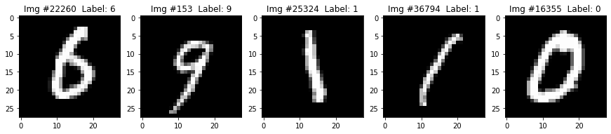

```python
fig, ax = plt.subplots(1,5)
fig.set_size_inches(15, 3)

ids = np.random.randint(low=0, high=len(our_train_db), size=5)

for i, n in enumerate(ids):
    img = our_train_db[n][0].numpy().reshape(28,28)
    ax[i].imshow(img, cmap='gray')
    ax[i].set_title(f"Img #{n}  Label: {our_train_db[n][1]}")
plt.show()
```

## Data Loaders

Data loaders provide an efficient way to iterate a Dataset object.

- https://pytorch.org/docs/stable/data.html#torch.utils.data.DataLoader

```python
BATCH_SIZE = 512
SHUFFLE = True
```

```python
eval_loader =  torch.utils.data.DataLoader(
        dataset=our_eval_db,
        batch_size=BATCH_SIZE,
        shuffle=SHUFFLE
    )
```

```python
imgs, labels = next(iter(eval_loader))
```

```python
imgs.shape
```

```
torch.Size([512, 1, 28, 28])
```

```python
for i, (imgs, labels) in enumerate(eval_loader):
    print(f"Iterating batch #{i+1}, which has {len(labels)} elements")
```

```
Iterating batch #1, which has 512 elements
Iterating batch #2, which has 512 elements
Iterating batch #3, which has 512 elements
Iterating batch #4, which has 512 elements
Iterating batch #5, which has 512 elements
Iterating batch #6, which has 512 elements
Iterating batch #7, which has 512 elements
Iterating batch #8, which has 512 elements
Iterating batch #9, which has 512 elements
Iterating batch #10, which has 512 elements
Iterating batch #11, which has 512 elements
Iterating batch #12, which has 512 elements
Iterating batch #13, which has 512 elements
Iterating batch #14, which has 512 elements
Iterating batch #15, which has 512 elements
Iterating batch #16, which has 512 elements
Iterating batch #17, which has 512 elements
Iterating batch #18, which has 512 elements
Iterating batch #19, which has 512 elements
Iterating batch #20, which has 272 elements
```

# Assignment 1

- Set Jupyter running in your home account so that you can use it remotely (Optional due to Covid-19!)
- Build **2 layer** network for Handwritten Digit Classification using pure python/numpy (without the layers from PyTorch)
  - Input data $\mathbf{x} : 20 \times 784$ ($20$ is the batch size, $784 = 28 \times 28$))
  - Hidden size 64
  - label $\mathbf{y} : 20 \times 10$
  - Weight Variable $\mathbf{W}$ with random initialization (e.g., Uniform[-0.5,0.5])
  - Bias variable $\mathbf{b}$ with zeros (no bias)
  - Sigmoid nonlinearity
  - Use softmax activation => $softmax( \mathbf{W} \cdot \mathbf{x} + \mathbf{b})$
  - Use OneHot encoding and MSE loss! Not the best way for classification but just for practice
  - Train the model on MNIST through gradient descent
  - PS: If you dont know how to start see this:
    - http://iamtrask.github.io/2015/07/12/basic-python-network/
    - http://neuralnetworksanddeeplearning.com/chap1.html
    - https://towardsdatascience.com/derivative-of-the-sigmoid-function-536880cf918e
    - https://aimatters.wordpress.com/2019/06/17/the-softmax-function-derivative/
- Submit your Jupyter Notebook (.ipynb) and an HTML export to villar@ais.uni-bonn.de with subject: **CudaLab: Assignment1**

#### Please use **CudaLab: Assignment1** for the subject of the mail

# References:

#### https://pytorch.org/docs/stable/index.html

#### https://pytorch.org/vision/stable/index.html

#### https://cs231n.github.io/

#### http://neuralnetworksanddeeplearning.com/